# ECON6027_7a_sols

Dr. Liu

2023-08-11

## Solutions to ECON6027_7a

```r
library(spdep, quietly = T); library(sf, quietly = T)
```

Data prep is done first. The variables of the UK dataset are:

GVA: gross value added

LP: labour productivity

PBB: percentage of new business births

```r
UK_nb = read.gal("UK_nb.gal") #read GAL from the last chapter
(W_list = nb2listw(UK_nb))
```

```
## Characteristics of weights list object:
## Neighbour list object:
## Number of regions: 12
## Number of nonzero links: 42
## Percentage nonzero weights: 29.16667
## Average number of links: 3.5
##
## Weights style: W
## Weights constants summary:
##    n  nn S0       S1       S2
## W 12 144 12 7.751111 50.16889
```

```r
uk_data = st_read("uk_data.shp")
names(uk_data)
```

```
##  [1] "objectd"  "nts118c"  "nts118n"  "bng_e"    "bng_n"    "long"
##  [7] "lat"      "st_arsh"  "st_lngt"  "gross_v"  "L_prod"   "pct_bsb"
## [13] "geometry"
```

```r
st_is_valid(uk_data)
```

```
##  [1] TRUE TRUE TRUE TRUE TRUE TRUE TRUE TRUE TRUE TRUE TRUE TRUE
```

```r
options(scipen = 999) # to remove “e” notation from the summary outputs
# options(scipen = 0) # to resore “e” notation
```

### Solutions A

- Model 1:

```r
model1 = lm(formula = gross_v ~ L_prod + pct_bsb, data=uk_data)
summary(model1)
```

```
##
## Call:
## lm(formula = gross_v ~ L_prod + pct_bsb, data = uk_data)
##
## Residuals:
##     Min      1Q  Median      3Q     Max
## -3.1398 -0.9172 -0.4388  1.0958  2.5365
##
## Coefficients:
##              Estimate Std. Error t value Pr(>|t|)
## (Intercept) -22.31118    3.38594  -6.589 0.000100 ***
## L_prod        0.27750    0.05346   5.191 0.000571 ***
## pct_bsb       0.42239    0.47243   0.894 0.394567
## ---
## Signif. codes:  0 '***' 0.001 '**' 0.01 '*' 0.05 '.' 0.1 ' ' 1
##
## Residual standard error: 1.791 on 9 degrees of freedom
## Multiple R-squared:  0.9072, Adjusted R-squared:  0.8866
## F-statistic: 43.99 on 2 and 9 DF,  p-value: 0.00002259
```

Conclusion: pct_bsb is not significant, but L_prod is significant.

- Model 2:

```r
model2 = lm(formula = gross_v ~ L_prod, data=uk_data)
summary(model2)
```

```
##
## Call:
## lm(formula = gross_v ~ L_prod, data = uk_data)
##
## Residuals:
##     Min      1Q  Median      3Q     Max
## -2.5300 -0.8375 -0.4193  1.0386  3.0149
##
## Coefficients:
##              Estimate Std. Error t value   Pr(>|t|)
## (Intercept) -21.38866    3.19237  -6.700 0.00005365 ***
## L_prod        0.31460    0.03335   9.432 0.00000271 ***
## ---
## Signif. codes:  0 '***' 0.001 '**' 0.01 '*' 0.05 '.' 0.1 ' ' 1
##
## Residual standard error: 1.773 on 10 degrees of freedom
## Multiple R-squared:  0.899,  Adjusted R-squared:  0.8889
## F-statistic: 88.97 on 1 and 10 DF,  p-value: 0.000002708
```

Conclusion: L_prod is significant.

- Model 3:

```r
model3 = lm(formula = gross_v ~ pct_bsb, data=uk_data)
summary(model3)
```

```
##
## Call:
## lm(formula = gross_v ~ pct_bsb, data = uk_data)
##
## Residuals:
##     Min      1Q  Median      3Q     Max
## -6.8006 -1.5308 -0.6353  1.8746  5.6300
##
## Coefficients:
##             Estimate Std. Error t value Pr(>|t|)
## (Intercept) -16.0547     5.9992  -2.676  0.02325 *
## pct_bsb       2.3264     0.5646   4.121  0.00208 **
## ---
## Signif. codes:  0 '***' 0.001 '**' 0.01 '*' 0.05 '.' 0.1 ' ' 1
##
## Residual standard error: 3.397 on 10 degrees of freedom
## Multiple R-squared:  0.6293, Adjusted R-squared:  0.5923
## F-statistic: 16.98 on 1 and 10 DF,  p-value: 0.002075
```

Conclusion: pct_bsb is significant, possibly due to omitted variable bias.

Alternatively, you can also consider AIC and BIC to compare.

```r
AIC(model1);AIC(model2);AIC(model3)
```

```
## [1] 52.59553
```

```
## [1] 51.61663
```

```
## [1] 67.2135
```

```r
BIC(model1);BIC(model2);BIC(model3)
```

```
## [1] 54.53516
```

```
## [1] 53.07135
```

```
## [1] 68.66822
```

Conclusion: model 2 has the lowest AIC and BIC.

- Model 4

```r
model4 = lm(formula = L_prod ~ pct_bsb, data=uk_data)
summary(model4)
```

```
##
## Call:
## lm(formula = L_prod ~ pct_bsb, data = uk_data)
##
## Residuals:
##     Min      1Q  Median      3Q     Max
## -13.192  -6.589  -2.225   4.571  16.980
##
## Coefficients:
##             Estimate Std. Error t value Pr(>|t|)
## (Intercept)   22.546     18.718   1.205  0.25613
## pct_bsb        6.861      1.761   3.895  0.00298 **
## ---
## Signif. codes:  0 '***' 0.001 '**' 0.01 '*' 0.05 '.' 0.1 ' ' 1
##
## Residual standard error: 10.6 on 10 degrees of freedom
## Multiple R-squared:  0.6027, Adjusted R-squared:  0.563
## F-statistic: 15.17 on 1 and 10 DF,  p-value: 0.002984
```

Conclusion: Given the significance of model 4, there maybe endogeneity in model 1.

#### Hypothesis tests

- Breusch–Pagan test

```r
lmtest::bptest(model1)
```

```
##
##  studentized Breusch-Pagan test
##
## data:  model1
## BP = 1.5183, df = 2, p-value = 0.4681
```

Conclusion: Null of homoskedasticity is not rejected. No evidence of heteroskedasticity.

- Jarque–Bera test

```r
tseries::jarque.bera.test(model1$residuals)
```

```
##
##  Jarque Bera Test
##
## data:  model1$residuals
## X-squared = 0.091982, df = 2, p-value = 0.9551
```

### Solutions B

Lagged labour productivity variable (W*L_prod)

```r
as.matrix(lag.listw(W_list,uk_data$L_prod)) # lagged L_prod
```

```
##            [,1]
##  [1,]  90.06667
##  [2,]  87.93333
##  [3,]  88.00000
##  [4,]  93.50000
##  [5,]  91.48000
##  [6,] 112.40000
##  [7,] 102.55000
##  [8,] 100.92000
##  [9,]  92.96667
## [10,]  89.16667
## [11,]  85.90000
## [12,]  96.90000
```

### Solutions C

We consider model 1

```r
(L_GVA = as.matrix(lag.listw(W_list,uk_data$gross_v))) # lagged gross_v
```

```
##            [,1]
##  [1,]  8.233333
##  [2,]  5.916667
##  [3,]  6.300000
##  [4,]  9.420000
##  [5,]  8.340000
##  [6,] 14.166667
##  [7,] 11.700000
##  [8,] 10.300000
##  [9,]  8.533333
## [10,]  8.166667
## [11,]  5.000000
## [12,]  8.300000
```

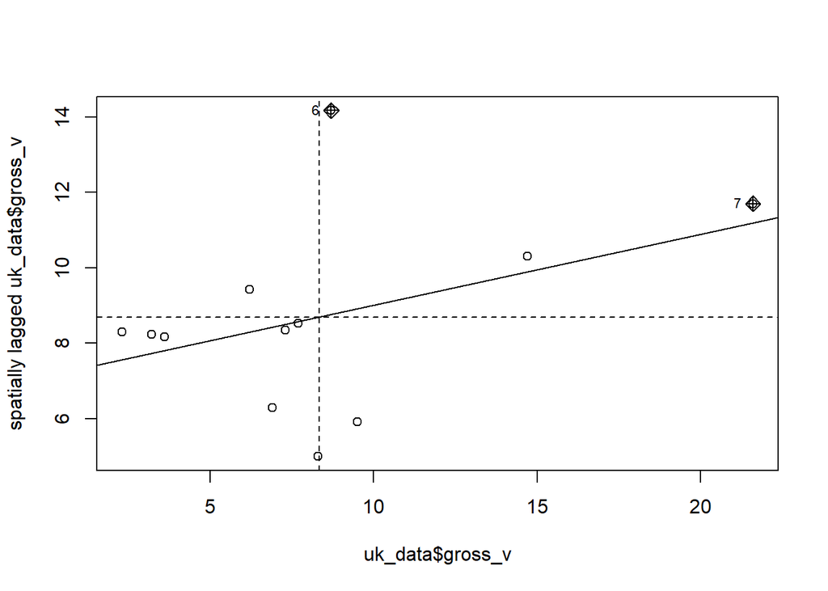

```r
moran.plot(uk_data$gross_v, W_list)
```

There seem to be positive spatial autocorrelation in the dependent variable “gross_v” with most points in the H-H (hotspots) and L-L quadrants (coldspots).

```r
moran.test(uk_data$gross_v, W_list)
```

```
##
##  Moran I test under randomisation
##
## data:  uk_data$gross_v
## weights: W_list
##
## Moran I statistic standard deviate = 1.6398, p-value = 0.05053
## alternative hypothesis: greater
## sample estimates:
## Moran I statistic       Expectation          Variance
##        0.18820554       -0.09090909        0.02897315
```

Conclusion: no evidence of spatial autocorrelation in the dependent variable at 5% level.

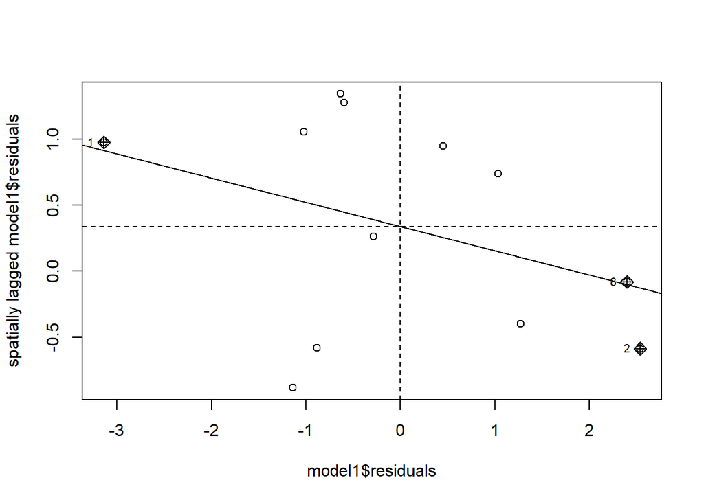

```r
moran.plot(model1$residuals, W_list)
```

```r
lm.morantest(model1, W_list) # Moran's test for regression residuals
```

```
##
##  Global Moran I for regression residuals
##
## data:
## model: lm(formula = gross_v ~ L_prod + pct_bsb, data = uk_data)
## weights: W_list
##
## Moran I statistic standard deviate = -0.17214, p-value = 0.5683
## alternative hypothesis: greater
## sample estimates:
## Observed Moran I      Expectation         Variance
##      -0.18356947      -0.15277051       0.03201064
```

Conclusion: Do not reject H0. No evidence of spatial autocorrelation in the OLS residuals.